# Guinea Pigs’ Toothgrowth Inferential Analysis For Two Delivery Methods

George Papadopoulos

pgeorgios8@gmail.com

09 March 2023

Abstract

In this small report we will analyze the “tooth-growth” dataset and perform the analysis in four steps:  
1. Load the “ToothGrowth” built-in dataset and perform some basic descriptive and exploratory data analysis.  
2. State and explore the assumptions needed for the tests we will conduct.  
3. Use confidence interval and/or hypothesis tests to compare tooth growth length by supp and dose.  
4. State our conclusions.

## Descriptive Analysis

The “ToothGrowth” data set contains sixty observations recording the response of tooth growth in vitamin C intake with response to doses of 0.5, 1 and 2 mg/day of sixty guinea pigs divided into two groups according to the delivery method OJ (orange juice) or VC (ascorbic acid). The data is already pre-loaded and for more information we can use the help function in R.

```r
help("ToothGrowth")
```

The dataset has three columns, the first column is the “len” continuous parameter that records the tooth length in millimeters, the second is the “supp” parameter that records a two level categorical variable with labels VC or OJ which are the types of supplements and finally the “dose” column which is a continuous parameter that records the doses in mg/day which are 0.5, 1 and 2 mg/day.

```r
str(ToothGrowth)
```

```
'data.frame':   60 obs. of  3 variables:
 $ len : num  4.2 11.5 7.3 5.8 6.4 10 11.2 11.2 5.2 7 ...
 $ supp: Factor w/ 2 levels "OJ","VC": 2 2 2 2 2 2 2 2 2 2 ...
 $ dose: num  0.5 0.5 0.5 0.5 0.5 0.5 0.5 0.5 0.5 0.5 ...
```

The dataset has no missing values, its first thirty entries are the observations recorded for the VC delivery method and the other thirty entries the respective observations for the OJ delivery method. In order to take a glimpse of how the data rows are recorded, the first six entries are

```r
head(ToothGrowth)
```

```
   len supp dose
1  4.2   VC  0.5
2 11.5   VC  0.5
3  7.3   VC  0.5
4  5.8   VC  0.5
5  6.4   VC  0.5
6 10.0   VC  0.5
```

the last six rows are

```r
tail(ToothGrowth)
```

```
    len supp dose
55 24.8   OJ    2
56 30.9   OJ    2
57 26.4   OJ    2
58 27.3   OJ    2
59 29.4   OJ    2
60 23.0   OJ    2
```

and finally the range of the variable we will examine thoroughly in the next sections is

```r
range(ToothGrowth$len)
```

```
[1]  4.2 33.9
```

from which we deduce that all our subjects in the sample developed a tooth regardless of the treatment intake.

## Exploratory Analysis

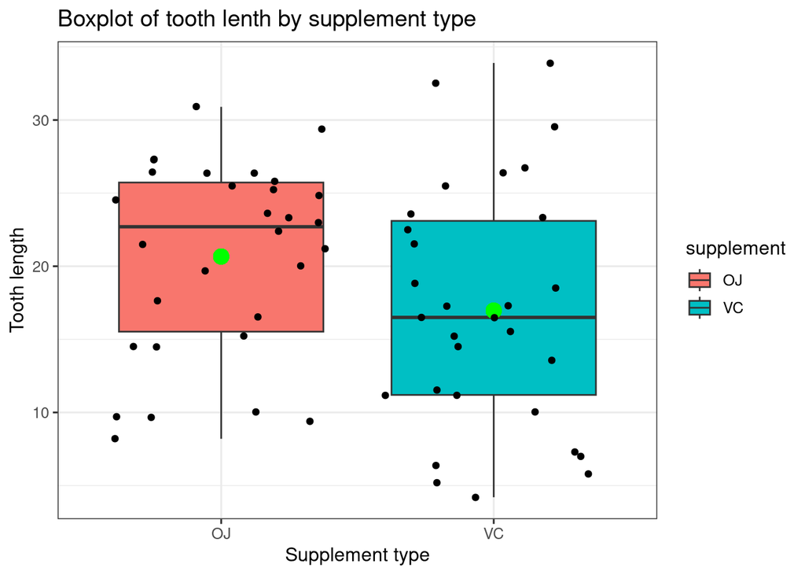

Tooth Length By Supplement Group

```r
library(ggplot2)
g <- ggplot(data = ToothGrowth, aes(x = supp,y = len)) +
        geom_boxplot(aes(fill = supp)) +
        xlab("Supplement type") +
        ylab("Tooth length") +
        ggtitle("Boxplot of tooth lenth by supplement type ") + theme_bw(base_size = 12)
g <- g + scale_fill_discrete(name = "supplement")
g <- g + geom_point(x = 1,y = mean(ToothGrowth$len[ToothGrowth$supp == "OJ"]),cex = 4,color = "green")
g <- g + geom_point(x = 2,y = mean(ToothGrowth$len[ToothGrowth$supp == "VC"]),cex = 4,color = "green") +
  geom_jitter()
g
```

The median of the tooth length of the subjects provided with orange juice is significantly bigger than the tooth growth length of the ascorbic acid delivery method and the interquantile 75% range of the OJ supplement type seems to be a little bit narrower that the VC supplement’s box implying same variability between the two groups. The two green points inside the boxes show the means of the two groups and it is obvious that the distance between the mean and median in group OJ implies skewness, something which isn’t visible in the “VC” group since the mean and the median fall close.

In the next figure we break down the responce in tooth length by dose in each group separately.

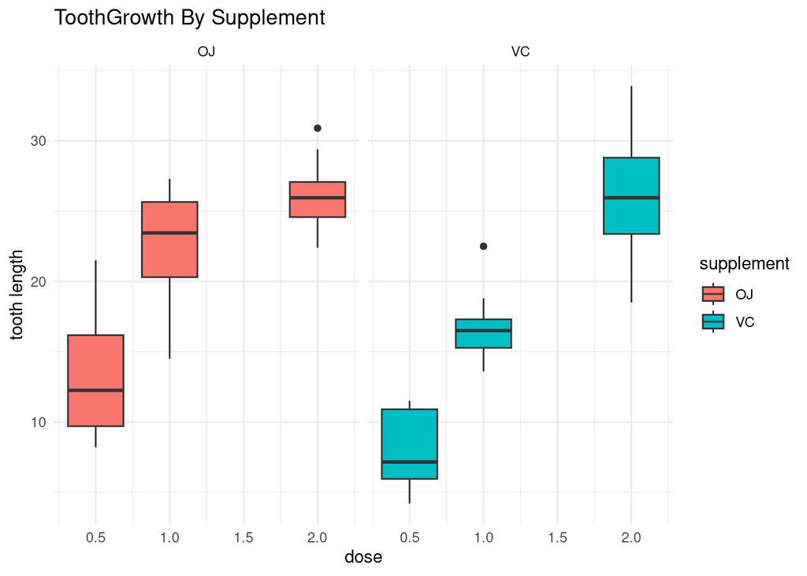

Tooth Length By Dose Per Group

```r
g <- ggplot(data = ToothGrowth,aes(x = dose,fill = supp))
g <- g + geom_boxplot(aes(y = len,group = dose))
g <- g + facet_grid(. ~ supp) + ggtitle("ToothGrowth By Supplement")
g <- g + theme_minimal()
g <- g + xlab("dose") + ylab("tooth length") + labs(fill = "supplement")
g
```

From a quick view it seems that the subjects provided with the supplement of orange juice respond with better results in tooth growth with doses 0.5 and 1 mg/day as it can be seen from the medians (black horizontal lines inside the boxes) and the placement of the boxes which is also higher than the group provided with the ascorbic acid supplement with the same doses respectively, but both methods perform almost well for a dose of 2 mg/day although the VC group’s lengths seem more spread for that dose. We also observe outliers for a dose of 2 mg/day and 1 mg/day for OJ and VC groups respectively, which might explain the cause of skewness as noted previously and it is obvious that the general trend is that the higher the dose per day the better the response in tooth length growth for both groups.

In the next figure we plot the density of the tooth lengths for the whole sample to examine if the lengths of the whole dataset come from a normally distributed population.

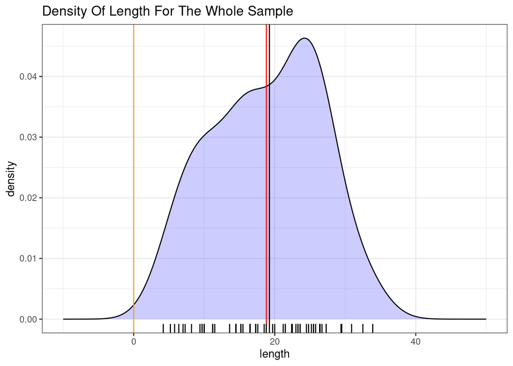

Density of Tooth Length Regardless Of Supplement

```r
g <- ggplot(data = ToothGrowth,aes(len))
g <- g + geom_density(stat = "density",position = "identity",fill = rgb(0,0,1,.2))
g <- g + xlim(c(-10,50)) + theme_bw() + labs(x = "length") + ggtitle("Density Of Length For The Whole Sample")
g <- g + geom_vline(xintercept = mean(ToothGrowth$len),colour = "red") +
  geom_vline(xintercept = median(ToothGrowth$len)) + geom_vline(xintercept = 0,colour = "orange") + geom_rug()
g
```

As expected the tooth lengths come from a normal distribution and the fact that we don’t see a perfect Gaussian distribution support with all the lengths over zero as seen from the small tail to the left of the orange vertical line might be attributed to the way that the program computes the density kernel which will not concern us but also to the small sample of sixty observations. So we accept as a fact that the dataset follows the normal distribution and that the whole distribution lies strictly over zero. Another observation is that the mean and the median, “red” and “black” vertical lines respectively are close implying that the skewness is almost zero, so with more observations and better experimental design for single/multiple hypothesis testing for a good statistical power over 80% for all tests, the support would fit a Gaussian normal distribution with tooth lengths in the x-axis strictly over zero.

In the next figure we visualize the tooth length densities separately by group, VC group seems normal and OJ slightly left skewed, in the VC group we observe that the support falls over lengths less than zero for the reasons we highlighted in the previous paragraph, but nonetheless we will consider the assumptions of normality valid for both treatment groups.

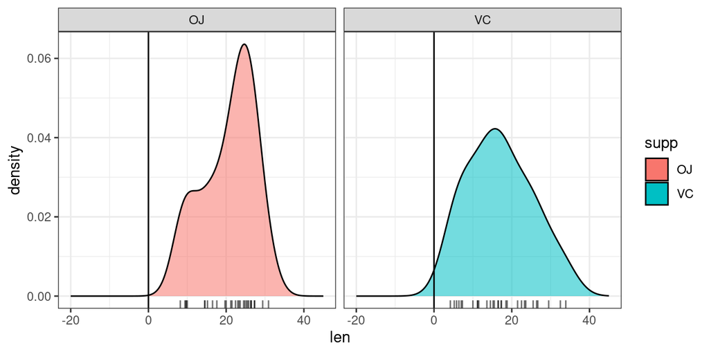

Density Of Tooth Length Per Supplement

```r
g <- ggplot(data = ToothGrowth,aes(len,fill = supp,alpha = .25))
g <- g + geom_density(stat = "density",position = "identity") + theme_bw()
g <- g + guides(alpha = "none")
g <- g + facet_grid(. ~ supp) + xlim(-20,45) + geom_vline(xintercept = 0) + geom_rug()
g
```

In the next figure we visualize the density of the tooth length per supplement divided in cells for each dose in mg/day in order to check deeper the reason behind the skewness in our data and the negative length values in the density plot of the VC treatment group.

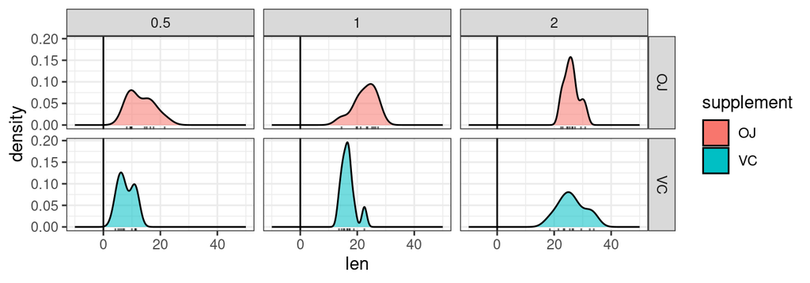

Density Of Tooth Length Per Supplement

```r
g <- ggplot(data = ToothGrowth,aes(len,fill = supp,alpha = .25))
g <- g + geom_density(stat = "density",position = "identity") + theme_bw()
g <- g + guides(alpha = "none")
g <- g + facet_grid(supp ~ dose) + xlim(c(-10,50))
g <- g + scale_fill_discrete(name = "supplement") + geom_vline(xintercept = 0) + geom_rug()
g
```

The OJ group tooth length distribution by dose seems normal regarding the fact that we only 10 have observations per dose in every cell. The length is strictly over zero in all cells, the 2 mg/day dose though presents an anomaly to the right of the peak of its density, which is explained by the outlier in the boxplot in figure 2 and we observe right and left skewness for 0.5 and 1.0 mg/day doses respectively.

The VC tooth length distribution for 0.5 mg/day dose seems to fall over lengths less than zero in the x axis and it is the only one in the group that does so, it is also slightly bimodal which explain why the sample’s tooth length distribution for VC treatment in figure 4 has a tail that falls over the negative tooth lengths, the middle cell VC for 1.0 mg/day has a small peak to the right of the center of the distribution, which is explained by the outlier in figure 2 and the last cell VC 2.0 mg/day seems normal with a large variance around the mean. We will consider that the assumption of normality is held for all cells generally and will overcome the fact that one distribution falls under the zero tooth length threshold.

## Statistical Inference

We are going to conduct two t statistical significance tests, the normality of the data which is a necessary condition for the t-test was discussed in the previous section and the skewness we observed in some distributions is overcome by the robustness of the t-test to skewed data if it isn’t extreme. The two one sided t-tests for a 5% significance level are:

- test 1: test if the mean tooth lengths for the whole data set is greater than zero.
- test 2: test if the difference of the means of the tooth lengths by supplement intake is significantly greater than zero, treating each group independently and assuming an equal variance across the two groups.

### Test 1

Hypotheses Statements

$\mathfrak{H}_{0}$: True mean of tooth growth lengths is less than or equal to zero.

$\mathfrak{H}_{a}$: True mean of tooth growth lengths is greater than zero.

```r
t.test(ToothGrowth$len,alternative = "greater")
```

```
    One Sample t-test

data:  ToothGrowth$len
t = 19.051, df = 59, p-value < 2.2e-16
alternative hypothesis: true mean is greater than 0
95 percent confidence interval:
 17.16309      Inf
sample estimates:
mean of x
 18.81333
```

The p-value of the test is significantly less than the 0.05 significance level, so we reject the null hypothesis and we accept the alternative which states that the true mean of the lengths regardless of the treatment is significantly greater than zero.

### Test 2

Hypotheses Statements

$\mathfrak{H}_{0}$: Tooth growth of treatment group OJ is less than or equal to the tooth growth response of the treatment group VC.

$\mathfrak{H}_{a}$: Tooth growth of treatment group OJ is greater than the tooth growth response of the treatment group VC.

```r
t.test(ToothGrowth$len[ToothGrowth$supp == "OJ"],ToothGrowth$len[ToothGrowth$supp == "VC"],
       var.equal = TRUE,alternative = "greater",type = "two.sample",alpha = 0.05)
```

```
    Two Sample t-test

data:  ToothGrowth$len[ToothGrowth$supp == "OJ"] and ToothGrowth$len[ToothGrowth$supp == "VC"]
t = 1.9153, df = 58, p-value = 0.0302
alternative hypothesis: true difference in means is greater than 0
95 percent confidence interval:
 0.4708204       Inf
sample estimates:
mean of x mean of y
 20.66333  16.96333
```

The p-value of the test is less that than the 0.05 significance level, so we reject the null hypothesis and accept the alternative hypothesis that the orange juice intake performs better.

## Non Parametric Techniques

### Bootstrap

Since we raised some concerns regarding the statistical power of the experimental design and about the normality of the data in our tests with the skewed figures in the first section, we will introduce in our report a non parametric technique named “bootstrap” which was developed by Stanford statistician Bradley Efron. We will create two samples of 30 observations taken from the original groups OJ and VC separately **with replacement** and then compare the means of the bootstrapped samples, we will repeat the process many times and after the end we will compute a p-value for the test by taking the mean of the instances in which the mean of bootstrapped VC sample was found greater than the mean of the OJ bootstrapped samples. The hypotheses in this setting are the same as in test 2 of the previous section. We could have used the “median” as a metric, but in bootstrap processes this metric is very sensitive to bias created by outliers and skewness, there are R packages that correct the bias but since we want a neat and simple code and not a package written by fellow data scientists the mean metric serves the purpose perfectly, since it is unbiased! The following simple code performs the bootstrap process within a few lines.

```r
boot_vec <- vector(mode = "numeric",length = 1e4)
for (ii in 1:1e4) {
  boot_A <- sample(ToothGrowth$len[ToothGrowth$supp == "OJ"],size = 30,replace = TRUE)
  boot_B <- sample(ToothGrowth$len[ToothGrowth$supp == "VC"],size = 30,replace = TRUE)
  if (mean(boot_B) > mean(boot_A)) {
    boot_vec[ii] <- 1
  }
}
mean(boot_vec)
```

```
[1] 0.0262
```

For ten thousand iterations the p-value we get is less than the significance level 0.05 so we reject the null hypothesis that the mean of the VC treatment groups is greater than the mean of the OJ group and accept that the OJ treatment performs better in tooth length growth response than the VC treatment group.

### Label Permutation Test

In this non parametric test we will examine if the labels of the treatment groups play a significant role in our tests. We will compute firstly the difference in means of the tooth lengths of the two treatment groups which will call the *original* difference in means and then for many repetitions of shuffling the supp labels and keeping all records in the other columns the same as in the original data, we will compute the difference in means permutation we will compare it to the *original* difference.

Hypotheses statements

$\mathfrak{H}_{0}$: After shuffling treatment labels many times, VC label performs better than OJ in tooth length response mean difference, so the labels are insignificant based on the second t-test we conducted previously.

$\mathfrak{H}_{0}$: The groups’ labels are significant in our tests, the OJ group performs better in tooth length response.

```r
me <- mean(ToothGrowth$len[ToothGrowth$supp == "OJ"] - ToothGrowth$len[ToothGrowth$supp == "VC"])
perm_vec <- vector(mode = "numeric",length = 1e4)
for (ii in 1:1e4) {
  label_perms <- sample(ToothGrowth$supp)
  perm_vec[ii] <- mean(ToothGrowth$len[label_perms == "VC"] - ToothGrowth$len[label_perms == "OJ"])
}
p_value <- mean(perm_vec > me)
print(p_value)
```

```
[1] 0.0286
```

The p-value is less than the 0.05 significance level and so the labels play a significant in our tests, the following figure depicts the distribution of the means computed in the previous coding chunk and the p-value.

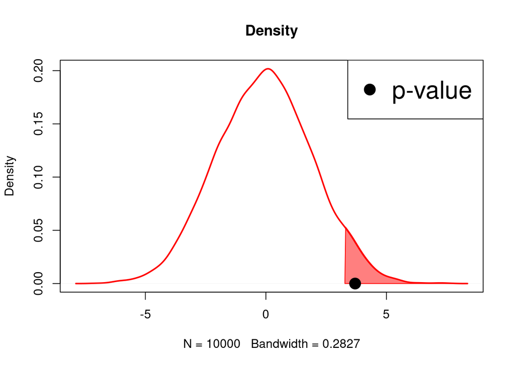

```r
dx <- density(perm_vec)
plot(dx, lwd = 2, main = "Density", col = "red")
polygon(c(dx$x[dx$x >= quantile(perm_vec,probs = .95)],quantile(perm_vec,probs = 1)),
        c(0,dx$y[dx$x >= quantile(perm_vec,probs = 0.95)]),
        col = rgb(1, 0, 0, alpha = 0.5), border = "red")
points(x = quantile(perm_vec,probs = 1 - p_value),y = 0,pch = 19,cex = 2)
legend("topright",legend = "p-value",pch = 19,cex = 2)
```

## Multiple Hypothesis Testing

At this section we will create a family of tests, we will compare all doses per two in the whole data set and adjust the p-values with the **bonferroni** correction for the family wise error rate, the tests are fifteen in number and will be stored in a list.

```r
all_tests <- list(
## t.test in OJ treatment group in length response per dose
p_.5OJ_1.0OJ = t.test(ToothGrowth$len[ToothGrowth$supp == "OJ" & ToothGrowth$dose == .5],
                      ToothGrowth$len[ToothGrowth$supp == "OJ" & ToothGrowth$dose == 1],alternative = "greater",
                      var.equal = T,paired = F,type = "two.sample")$p.value,
p_1.0J_2.0OJ = t.test(ToothGrowth$len[ToothGrowth$supp == "OJ" & ToothGrowth$dose == 1],
                      ToothGrowth$len[ToothGrowth$supp == "OJ" & ToothGrowth$dose == 2],alternative = "greater",
                      var.equal = T,paired = F,type = "two.sample")$p.value,
p_.5OJ_2.OJ  = t.test(ToothGrowth$len[ToothGrowth$supp == "OJ" & ToothGrowth$dose == .5],
                      ToothGrowth$len[ToothGrowth$supp == "OJ" & ToothGrowth$dose == 2],alternative = "greater",
                      var.equal = T,paired = F,type = "two.sample")$p.value,
## t.test in VC treatment group in length response per dose
p_.5VC_1.0VC  = t.test(ToothGrowth$len[ToothGrowth$supp == "VC" & ToothGrowth$dose == .5],
                      ToothGrowth$len[ToothGrowth$supp == "VC" & ToothGrowth$dose == 1],alternative = "greater",
                      var.equal = T,paired = F,type = "two.sample")$p.value,
p_1.0VC_2.0VC = t.test(ToothGrowth$len[ToothGrowth$supp == "VC" & ToothGrowth$dose == 1],
                      ToothGrowth$len[ToothGrowth$supp == "VC" & ToothGrowth$dose == 2],alternative = "greater",
                      var.equal = T,paired = F,type = "two.sample")$p.value,
p_.5VC_2.0VC  = t.test(ToothGrowth$len[ToothGrowth$supp == "VC" & ToothGrowth$dose == .5],
                      ToothGrowth$len[ToothGrowth$supp == "VC" & ToothGrowth$dose == 2],alternative = "greater",
                      var.equal = T,paired = F,type = "two.sample")$p.value,
## t.test 0.5 OJ compared to all VC doses
p_.5OJ_.5VC  = t.test(ToothGrowth$len[ToothGrowth$supp == "OJ" & ToothGrowth$dose == .5],
                      ToothGrowth$len[ToothGrowth$supp == "VC" & ToothGrowth$dose == .5],alternative = "greater",
                      var.equal = T,paired = F,type = "two.sample")$p.value,
p_.5OJ_1.0VC = t.test(ToothGrowth$len[ToothGrowth$supp == "OJ" & ToothGrowth$dose == .5],
                      ToothGrowth$len[ToothGrowth$supp == "VC" & ToothGrowth$dose == 1],alternative = "greater",
                      var.equal = T,paired = F,type = "two.sample")$p.value,
p_.5OJ_2.0VC = t.test(ToothGrowth$len[ToothGrowth$supp == "OJ" & ToothGrowth$dose == .5],
                      ToothGrowth$len[ToothGrowth$supp == "VC" & ToothGrowth$dose == 2],alternative = "greater",
                      var.equal = T,paired = F,type = "two.sample")$p.value,
## t.test 1.OJ compared to all VC  doses
p_1.0ΟJ_.5VC  = t.test(ToothGrowth$len[ToothGrowth$supp == "OJ" & ToothGrowth$dose == 1.0],
                      ToothGrowth$len[ToothGrowth$supp == "VC" & ToothGrowth$dose == .5],alternative = "greater",
                      var.equal = T,paired = F,type = "two.sample")$p.value,
p_1.0OJ_1.0VC = t.test(ToothGrowth$len[ToothGrowth$supp == "OJ" & ToothGrowth$dose == 1.0],
                      ToothGrowth$len[ToothGrowth$supp == "VC" & ToothGrowth$dose == 1],alternative = "greater",
                      var.equal = T,paired = F,type = "two.sample")$p.value,
p_1.0OJ_2.0VC = t.test(ToothGrowth$len[ToothGrowth$supp == "OJ" & ToothGrowth$dose == 2.0],
                      ToothGrowth$len[ToothGrowth$supp == "VC" & ToothGrowth$dose == 2],alternative = "greater",
                      var.equal = T,paired = F,type = "two.sample")$p.value,
## t.test 2.0OJ compared to all VC doses
p_2.0OJ_.5VC  = t.test(ToothGrowth$len[ToothGrowth$supp == "OJ" & ToothGrowth$dose == 2],
                      ToothGrowth$len[ToothGrowth$supp == "VC" & ToothGrowth$dose == .5],alternative = "greater",
                      var.equal = T,paired = F,type = "two.sample")$p.value,
p_2.0OJ_1.0VC = t.test(ToothGrowth$len[ToothGrowth$supp == "OJ" & ToothGrowth$dose == 2],
                      ToothGrowth$len[ToothGrowth$supp == "VC" & ToothGrowth$dose == 1],alternative = "greater",
                      var.equal = T,paired = F,type = "two.sample")$p.value,
p_2.0OJ_2.0VC = t.test(ToothGrowth$len[ToothGrowth$supp == "OJ" & ToothGrowth$dose == 2],
                      ToothGrowth$len[ToothGrowth$supp == "VC" & ToothGrowth$dose == 2],alternative = "greater",
                      var.equal = T,paired = F,type = "two.sample")$p.value)
p.adjust(all_tests,method = "bonferroni")
```

```
 p_.5OJ_1.0OJ  p_1.0J_2.0OJ   p_.5OJ_2.OJ  p_.5VC_1.0VC p_1.0VC_2.0VC
 1.000000e+00  1.000000e+00  1.000000e+00  1.000000e+00  1.000000e+00
 p_.5VC_2.0VC   p_.5OJ_.5VC  p_.5OJ_1.0VC  p_.5OJ_2.0VC  p_1.0ΟJ_.5VC
 1.000000e+00  3.977746e-02  1.000000e+00  1.000000e+00  1.002947e-07
p_1.0OJ_1.0VC p_1.0OJ_2.0VC  p_2.0OJ_.5VC p_2.0OJ_1.0VC p_2.0OJ_2.0VC
 5.855446e-03  1.000000e+00  1.003580e-10  1.734831e-06  1.000000e+00
```

The non significant results comply with the exploratory analysis findings that the higher the dose the better the results regardless of the treatment OJ or VC and that for 2.0 mg/day dose the OJ and VC perform almost the same in tooth growth length. The significant results on the other hand are P_.5OJ_.5VC, P_1.0OJ_.5VC, P_1.0OJ_1.0VC, p_2.0OJ_.5VC and p_2.0OJ_1.0VC from which we accept that for s dose of 0.5 mg/day OJ performs better than VC, 1.0 mg/day OJ better than .5 and 1.0 mg/day VC and 2.0 mg/day OJ better than .5 mg/day and 1.0 mg/day VC treatment in response to tooth growth length.

## Conclusions

The final conclusion is that OJ treatment group showed better results with doses of 0.5 and 1.0 mg/day and the 2.0 mg/day the same results compared to the VC treatment group doses respectively, the general trend for both groups was that the bigger the dose the better the response in response to tooth growth length.